# Tarea 2

## Challenge 1

*Nombre y apellidos*: Joaquín Paolo Mori Reinoso *Código*: 20211686

En la presente tarea se realizará la creación de mapas para el país de Uruguay. En la graficación, se podrán observar las ciudades, los aereopuertos,  
los ríos y sus municipios. En primera instancia, se realizará la preparación de la información y geodata para que esté proyectada y pueda ser  
interpretada correctamente.

## Importación de data

Se procede a importar la geodata para ser comprendida en el análisis y psoteriormente seleccionada para la creación de los mapas relevantes para el caso uruguayo.

```python
import os, geopandas as gpd

countries=gpd.read_file(os.path.join("data","World_Countries","World_Countries.shp"))
rivers=gpd.read_file(os.path.join("data","World_Hydrography","World_Hydrography.shp"))
cities=gpd.read_file(os.path.join("data","World_Cities","World_Cities.shp"))
```

```python
countries.head()
```

|  | COUNTRY | geometry |
| --- | --- | --- |
| 0 | Aruba (Netherlands) | POLYGON ((-69.88223 12.41111, -69.94695 12.436... |
| 1 | Antigua and Barbuda | MULTIPOLYGON (((-61.73889 17.54055, -61.75195 ... |
| 2 | Afghanistan | POLYGON ((61.27656 35.60725, 61.29638 35.62853... |
| 3 | Algeria | POLYGON ((-5.15213 30.18047, -5.13917 30.19236... |
| 4 | Azerbaijan | MULTIPOLYGON (((46.54037 38.87559, 46.49554 38... |

Se revisa que no hayan valores perdidos

```python
countries[countries.isna().any(axis=1)]
```

|  | COUNTRY | geometry |
| --- | --- | --- |

```python
countries.info()
```

```
<class 'geopandas.geodataframe.GeoDataFrame'>
RangeIndex: 252 entries, 0 to 251
Data columns (total 2 columns):
 #   Column    Non-Null Count  Dtype
---  ------    --------------  -----
 0   COUNTRY   252 non-null    object
 1   geometry  252 non-null    geometry
dtypes: geometry(1), object(1)
memory usage: 4.1+ KB
```

Se procede a realizar la graficación de los mapas. A continuación, se realizará la graficación de los polígonos, puntos y líneas para posteriormente unificar la data. Sin embargo, antes se debe revisar si los mapas están en la misma proyección.

```python
countries.crs==cities.crs==cities.crs
```

```
True
```

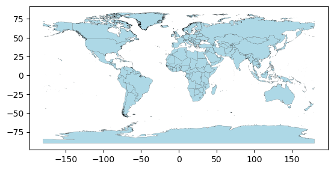

```python
countries.plot(facecolor="lightblue",
               edgecolor='black',
               linewidth=0.1)
```

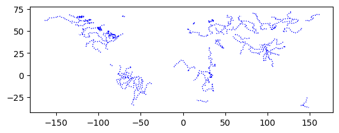

```python
rivers.plot(edgecolor='blue',
            linewidth=1,
            linestyle='dotted')
```

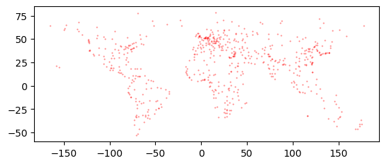

```python
cities.plot(marker='.',
            color='red',
            markersize=1,
            alpha=0.5)
```

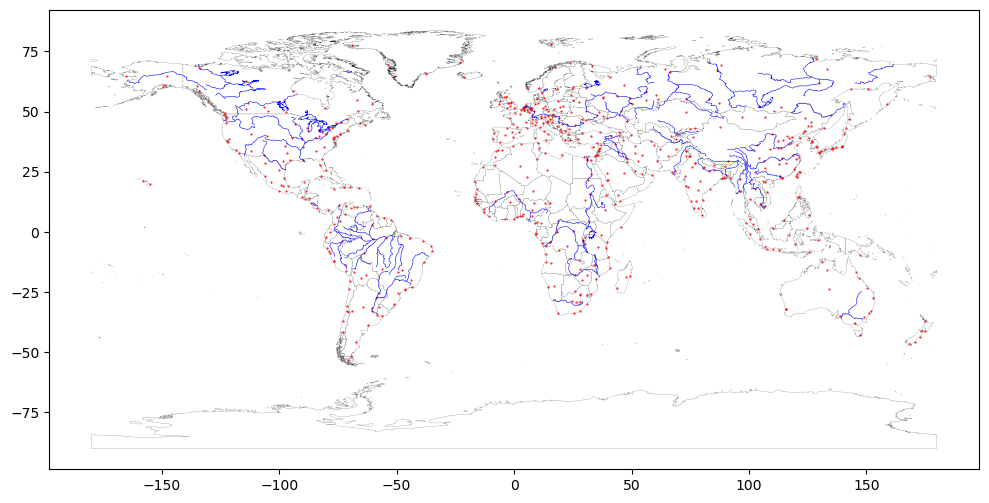

```python
base = countries.plot(facecolor="white",
                      edgecolor='black',
                      linewidth=0.1,
                      figsize=(12,12))

rivers.plot(edgecolor='blue', linewidth=0.4,
            ax=base)

cities.plot(marker='.', color='red', markersize=1,
            ax=base)
```

```python
countries.to_file(os.path.join("data","worldMap.gpkg"),layer='countryBorders', driver="GPKG")
rivers.to_file(os.path.join("data","worldMap.gpkg"),layer='riverLines', driver="GPKG")
cities.to_file(os.path.join("data","worldMap.gpkg"),layer='cityPoints', driver="GPKG")
```

## Selección del país - Uruguay

A continuación se filtrarán los países para seleccionar únicamente Uruguay. De esta manera se utilizará la función filter y clip para trabajar únicamente con la información de Uruguay.

```python
uruguay=countries[countries.COUNTRY=='Uruguay']
```

```python
citiesUruguay_clipped = gpd.clip(gdf=cities,
                          mask=uruguay)
riversUruguay_clipped = gpd.clip(gdf=rivers,
                               mask=uruguay)
```

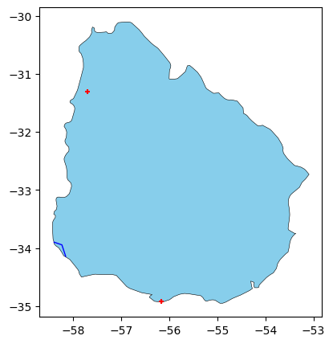

```python
base = uruguay.plot(facecolor="skyblue", edgecolor='black', linewidth=0.4,figsize=(5,5))
citiesUruguay_clipped.plot(marker='+', color='red', markersize=20,
                    ax=base)
riversUruguay_clipped.plot(edgecolor='blue', linewidth=1,
                    ax=base)
```

### Proyección

Se revisará la proyección del mapa para evitar problemas en las formas, áreas, escalas y dirección del mapa.

```python
print(uruguay.crs)
```

```
EPSG:4326
```

```python
uruguay.crs.axis_info
```

```
[Axis(name=Geodetic latitude, abbrev=Lat, direction=north, unit_auth_code=EPSG, unit_code=9122, unit_name=degree),
 Axis(name=Geodetic longitude, abbrev=Lon, direction=east, unit_auth_code=EPSG, unit_code=9122, unit_name=degree)]
```

### Reproyección

El CRS de Uruguay según [ESPEG.IO](https://epsg.io/?q=uruguay+kind%3APROJCRS) es de 5382. Por ello se realizarán las verificaciones de acuerdo al dato del centroide.

```python
uruguay.centroid
```

```
231    POINT (-56.01240 -32.79965)
dtype: geometry
```

```python
uruguay.to_crs(5382).crs.axis_info
```

```
[Axis(name=Easting, abbrev=E, direction=east, unit_auth_code=EPSG, unit_code=9001, unit_name=metre),
 Axis(name=Northing, abbrev=N, direction=north, unit_auth_code=EPSG, unit_code=9001, unit_name=metre)]
```

```python
uruguay.to_crs(5382).centroid
```

```
231    POINT (591892.564 6371340.027)
dtype: geometry
```

Se replotea para demostrar el centroide en el caso de Uruguay

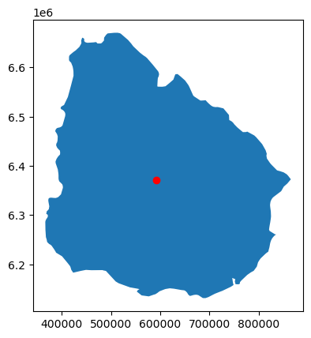

```python
base5382=uruguay.to_crs(5382).plot()
uruguay.to_crs(5382).centroid.plot(color='red',ax=base5382)
```

Se procede a guardar la información de la reproyección del mapa de Uruguay y los geopackages por capas en la carpeta data

```python
uruguay_5382=uruguay.to_crs(5382)
cities_uruguay_5382=citiesUruguay_clipped.to_crs(uruguay_5382.crs)
rivers_uruguay_5382=riversUruguay_clipped.to_crs(uruguay_5382.crs)
```

```python
import os
uruguay_5382.to_file(os.path.join("data","uruguayMaps_5382.gpkg"), layer='country', driver="GPKG")
cities_uruguay_5382.to_file(os.path.join("data","uruguayMaps_5382.gpkg"), layer='cities', driver="GPKG")
rivers_uruguay_5382.to_file(os.path.join("data","uruguayMaps_5382.gpkg"), layer='rivers', driver="GPKG")
```

```python
uruguay_5382.centroid
```

```
231    POINT (591892.564 6371340.027)
dtype: geometry
```

```python
uruguay_5382.centroid.to_file(os.path.join("data","uruguayMaps_5382.gpkg"), layer='centroid', driver="GPKG")
```

## Adición de información espacial (aeropuertos)

En esta sección se agregará la información sobre aeropuertos para complementar la graficación de los mapas

```python
import pandas as pd
infoairports=pd.read_csv(os.path.join("data","uy-airports.csv"))

# some rows

infoairports.iloc[[0,1,2,3,-4,-3,-2,-1],:] #head and tail
```

|  | id | ident | type | name | latitude_deg | longitude_deg | elevation_ft | continent | country_name | iso_country | ... | municipality | scheduled_service | gps_code | iata_code | local_code | home_link | wikipedia_link | keywords | score | last_updated |
| --- | --- | --- | --- | --- | --- | --- | --- | --- | --- | --- | --- | --- | --- | --- | --- | --- | --- | --- | --- | --- | --- |
| 0 | 6247 | SUMU | large_airport | Carrasco General Cesáreo L. Berisso Internatio... | -34.835647 | -56.026497 | 105.0 | SA | Uruguay | UY | ... | Ciudad de la Costa | 1 | SUMU | MVD | NaN | NaN | https://en.wikipedia.org/wiki/Carrasco_Interna... | Montevideo | 1275 | 2022-10-27T14:30:14+00:00 |
| 1 | 6246 | SULS | medium_airport | Capitan Corbeta CA Curbelo International Airport | -34.855099 | -55.094299 | 95.0 | SA | Uruguay | UY | ... | Punta del Este | 1 | SULS | PDP | NaN | http://www.puntadeleste.aero/ | https://en.wikipedia.org/wiki/Capitan_Corbeta_... | NaN | 500 | 2024-06-09T20:10:48+00:00 |
| 2 | 32390 | SUPE | small_airport | El Jagüel / Punta del Este Airport | -34.909716 | -54.920212 | 66.0 | SA | Uruguay | UY | ... | Maldonado | 1 | SUPE | NaN | NaN | NaN | https://en.wikipedia.org/wiki/El_Jag%C3%BCel_A... | NaN | 150 | 2024-05-18T23:28:54+00:00 |
| 3 | 6245 | SUDU | medium_airport | Santa Bernardina International Airport | -33.358898 | -56.499199 | 305.0 | SA | Uruguay | UY | ... | Durazno | 0 | SUDU | DZO | NaN | NaN | https://en.wikipedia.org/wiki/Santa_Bernardina... | NaN | 475 | 2024-05-17T07:24:01+00:00 |
| 65 | 533490 | UY-0028 | heliport | Helipad | -34.825459 | -54.658197 | 15.0 | SA | Uruguay | UY | ... | Jose Ignacio | 0 | NaN | NaN | NaN | NaN | NaN | NaN | 0 | 2024-06-15T18:11:19+00:00 |
| 66 | 325619 | SUEL | heliport | Liberty Building Helipad | -34.868763 | -56.166733 | 275.0 | SA | Uruguay | UY | ... | Montevideo | 0 | SUEL | NaN | NaN | NaN | NaN | NaN | 0 | 2017-11-26T13:20:06+00:00 |
| 67 | 324370 | UY-0003 | closed | Carlos M Fraschini Airport | -32.246237 | -58.093017 | 66.0 | SA | Uruguay | UY | ... | Paysandu | 0 | NaN | NaN | NaN | NaN | NaN | NaN | 0 | 2020-10-16T16:33:42+00:00 |
| 68 | 517338 | UY-0025 | heliport | Atchugarry Foundation Heliport | -34.865038 | -54.825127 | 109.0 | SA | Uruguay | UY | ... | Pueblo Garzon | 0 | NaN | NaN | 1002 | NaN | NaN | NaN | 0 | 2023-12-19T00:33:32+00:00 |

8 rows × 23 columns

```python
infoairports.columns
```

```
Index(['id', 'ident', 'type', 'name', 'latitude_deg', 'longitude_deg',
       'elevation_ft', 'continent', 'country_name', 'iso_country',
       'region_name', 'iso_region', 'local_region', 'municipality',
       'scheduled_service', 'gps_code', 'iata_code', 'local_code', 'home_link',
       'wikipedia_link', 'keywords', 'score', 'last_updated'],
      dtype='object')
```

```python
keep=['name','type','latitude_deg', 'longitude_deg','elevation_ft','region_name','municipality']
infoairports=infoairports.loc[:,keep]
```

```python
numericCols=['latitude_deg', 'longitude_deg','elevation_ft']
infoairports[numericCols]=infoairports.loc[:,numericCols].apply(lambda x:pd.to_numeric(x))

infoairports.info()
```

```
<class 'pandas.core.frame.DataFrame'>
RangeIndex: 69 entries, 0 to 68
Data columns (total 7 columns):
 #   Column         Non-Null Count  Dtype
---  ------         --------------  -----
 0   name           69 non-null     object
 1   type           69 non-null     object
 2   latitude_deg   69 non-null     float64
 3   longitude_deg  69 non-null     float64
 4   elevation_ft   66 non-null     float64
 5   region_name    69 non-null     object
 6   municipality   68 non-null     object
dtypes: float64(3), object(4)
memory usage: 3.9+ KB
```

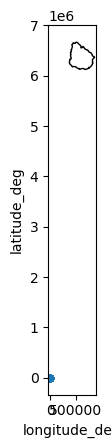

```python
base = uruguay_5382.plot(color='white', edgecolor='black')

infoairports.plot.scatter(x = 'longitude_deg', y = 'latitude_deg',ax=base)
```

```python
airports=gpd.GeoDataFrame(data=infoairports.copy(),
                 geometry=gpd.points_from_xy(infoairports.longitude_deg,
                                             infoairports.latitude_deg),
                 crs=uruguay.crs.to_epsg())
```

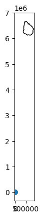

```python
base = uruguay_5382.plot(color='white', edgecolor='black')
airports.plot(ax=base)
```

```python
type(airports), type(infoairports)
```

```
(geopandas.geodataframe.GeoDataFrame, pandas.core.frame.DataFrame)
```

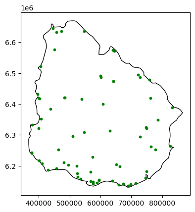

```python
airports_5382=airports.to_crs(5382)

base = uruguay_5382.plot(color='white', edgecolor='black')
airports_5382.plot(ax=base, markersize=10, color='green')
```

```python
airports_5382['type'].value_counts()
```

```
type
small_airport     59
medium_airport     4
heliport           4
large_airport      1
closed             1
Name: count, dtype: int64
```

```python
airports_5382.rename(columns={'type':'kind'},inplace=True)
```

```python
airports_5382.to_file(os.path.join("data","uruguayMaps_5641.gpkg"), layer='airports', driver="GPKG")
```

### Agregar a los mapas anteriores

A continuación, se agregará el mapa de los aeropuertos a los mapas ya realizados (ciudades y ríos)

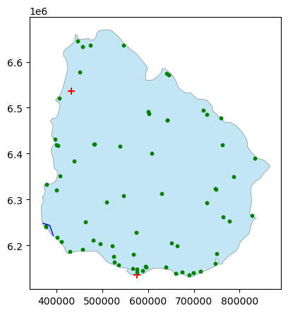

```python
base = uruguay_5382.plot(facecolor="skyblue", edgecolor='black', alpha=0.5, linewidth=0.4,figsize=(5,5))
cities_uruguay_5382.plot(marker='+', color='red', markersize=50,
                    ax=base)
rivers_uruguay_5382.plot(edgecolor='blue', linewidth=1,
                    ax=base)
airports_5382.plot(ax=base, markersize=10, color='green')
```

## Agregar límites administrativos de Uruguay

El territorio adminsitrativo de Uruguay está políticamente dividio en 19 departamentos. Para el ejercicio, se ejecutará la división por departamentos ya que no existe un equivalente apropiado a provincias.

```python
limites = gpd.read_file(os.path.join("data", "limitesDepartamentales_SHP", "Departamentos.shp"))
```

```python
limites_5382 = limites.to_crs(5382)
```

## Creación del Mapa de Uruguay

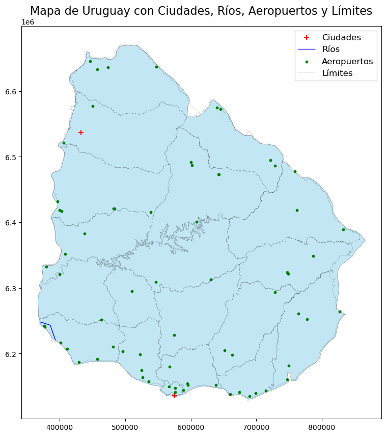

```python
import matplotlib.pyplot as plt
fig, ax = plt.subplots(figsize=(10, 10))

base = uruguay_5382.plot(ax=ax, facecolor="skyblue", edgecolor='black', alpha=0.5, linewidth=0.4)
cities_uruguay_5382.plot(ax=base, marker='+', color='red', markersize=50, label='Ciudades')
rivers_uruguay_5382.plot(ax=base, edgecolor='blue', linewidth=1, label='Ríos')
airports_5382.plot(ax=base, markersize=10, color='green', label='Aeropuertos')

limites_5382.plot(ax=base, edgecolor='black', linewidth=0.1, label='Límites')

ax.set_title("Mapa de Uruguay con Ciudades, Ríos, Aeropuertos y Límites", fontsize=16)

ax.legend(loc='upper right', fontsize=12)

plt.show()
```

En este mapa, se pueden observar las divisiones administrativas por departamento. En esta se pueden observar los aeropuertos que se ubican dentro del territorio uruguayo. Sin embargo, acerca de los ríos y ciudades, se podría argumentar que la información geográfica es incorrecta. A pesar de que la cateogrización de las ciudades puede depender de la cantidad de habitantes, Uruguay cuenta con más centros urbanos que los señalados. Una posible razón es la población que habita el territorio se concentra, sobre todo, en la capital y otras ciudades importantes. Por otro lado, sobre los ríos, en Uruguay existen más cuerpos de agua como ríos o lagos; sin embargo, la graficación solo muestra un segmento del río Uruguay que atraviesa varios países de la región. Para evitar estos problemas, sería importante utilizar información propia del país y de sus instituciones para graficar un mapa mucho más detallado.

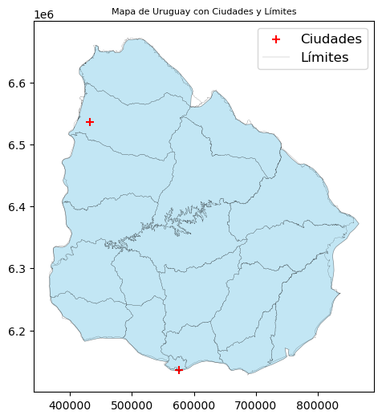

```python
import matplotlib.pyplot as plt
fig, ax = plt.subplots(figsize=(6, 6))

base = uruguay_5382.plot(ax=ax, facecolor="skyblue", edgecolor='black', alpha=0.5, linewidth=0.4)
cities_uruguay_5382.plot(ax=base, marker='+', color='red', markersize=50, label='Ciudades')
limites_5382.plot(ax=base, edgecolor='black', linewidth=0.1, label='Límites')

ax.set_title("Mapa de Uruguay con Ciudades y Límites", fontsize=8)

ax.legend(loc='upper right', fontsize=12)

plt.show()
```

[figure not shown]

```python
import matplotlib.pyplot as plt
fig, ax = plt.subplots(figsize=(6, 6))

base = uruguay_5382.plot(ax=ax, facecolor="skyblue", edgecolor='black', alpha=0.5, linewidth=0.4)
rivers_uruguay_5382.plot(ax=base, edgecolor='blue', linewidth=1, label='Ríos')
limites_5382.plot(ax=base, edgecolor='black', linewidth=0.1, label='Límites')

ax.set_title("Mapa de Uruguay con Ciudades y Ríos", fontsize=8)

ax.legend(loc='upper right', fontsize=12)

plt.show()
```

[figure not shown]

```python
import matplotlib.pyplot as plt
fig, ax = plt.subplots(figsize=(6, 6))

base = uruguay_5382.plot(ax=ax, facecolor="skyblue", edgecolor='black', alpha=0.5, linewidth=0.4)
airports_5382.plot(ax=base, markersize=10, color='green', label='Aeropuertos')
limites_5382.plot(ax=base, edgecolor='black', linewidth=0.1, label='Límites')

ax.set_title("Mapa de Uruguay con Ciudades y Aeropuertos", fontsize=8)

ax.legend(loc='upper right', fontsize=12)

plt.show()
```